# Introduction to Statistical Learning

9/3/2019

## About the last pop quiz

## 1. Definition of statistic

It is a quantity that depends on the sample data. It could be obtained by applying any mathematical function to the values found in a sample of data.

Examples of statistic include:

- sample mean: \(\bar{x} = (x_1 + \dots + x_n) \ / \ n\)
- sample variance: \(s^2 = \sum_{i = 1}^{n} (x_i - \bar{x})^2 \ / \ (n - 1)\)
- sample quantiles
- test statistics (t statistics, chi-squared statistics, F statistics, …)

## 2. Random variable

A random variable \(X\) is a function, a mapping from a random outcome to a real number. It represents each possible random outcome with a **numerical value**.

Examples:

1. Bernoulli random variable \(X \sim \text{Be}(p)\). The two possible outcomes \(X = 1\) and \(X = 0\) happen with probabilities \(p\) and \(1 - p\), respectively
2. Using a random variable \(X\) to describe the average price per square foot of a house at Austin
3. Using a random variable \(X\) to describe the total number of heads observed by flipping a coin twice

## 2. Random variable (ctd.)

Each numerical value of \(X\) is associated with a probability; the function that describes the probability of all possible values of \(X\) is called p.d.f (p.m.f in the discrete case), denoted via \(p(x) = \mathbb{P}(X = x)\).

Examples:

1. Bernoulli p.m.f: \(p(k) = \theta^{k} (1 - \theta)^{1 - k}, k \in \{0, 1\}\)
2. Normal p.d.f: \(p(x) = \dfrac{1}{\sqrt{2 \pi \sigma^2}} e^{- \frac{1}{2 \sigma^2} (x - \mu)^2}\)
3. \(X = \text{"number of heads observed by flipping a coin twice"}\), \[p(k) = \begin{cases} 0.25 &\text{ if } k = 0 \\ 0.5 &\text{ if } k = 1 \\ 0.25 &\text{ if } k = 2 \end{cases}\]

## 3. Normal distribution

It is a **continous** distribution.

[figure not shown]

## 4. Confidence Intervals

In my opinion, one of the least intuitive definitions in statistics. It is neither about confidence nor about probability.

Statistical inference steps:

1. We want to infer a parameter, say \(\mu\), representing the height of the UT college **population**
2. We collect a **sample** of data of UT students, \(x_1, \dots, x_n\)
3. We compute an **estimate**, in this case the average \(\bar{x}\). This represents the exact average height in my sample, NOT the true mean height of the population
4. To quantify uncertainty, we calculate a **CI**, in this case \(\left[\bar{x} + t_{\alpha/2,n-1} \frac{s_n}{\sqrt{n}}; \bar{x} + t_{1 - \alpha/2,n-1} \frac{s_n}{\sqrt{n}}\right]\), where \(\alpha\) is the significance level

If we were to repeat the procedure \(100\) times, \(\mu\) would be in the CI approximately 95 times out of 100 (in the case \(\alpha = 5\%\)).

## 5. Central Limit Theorem

Do not confuse with the law of large numbers. It is a theorem about the distribution of the **sample means** from a population.

Suppose \(X_1, X_2, \dots, X_n\) is a sequence of i.i.d. random variables (not necessarily normal) with well defined mean \(\mu\) and variance \(\sigma^2\). Then, as \(n\) approaches infinity, the random variable \[\frac{X_1 + \dots + X_n}{n} \rightarrow \mathcal{N}(\mu, \sigma^2 / n)\]

## Introduction to Statistical Learning

## Agenda for today

- Regression example
- Parametric vs nonparametric models
- Measuring accuracy
- **Bias-variance tradeoff**
- Classification example

## Supervised learning

- Outcome measurement \(Y\), also called response, target, dependent variable
- Vector of \(p\) predictor measurements \(X\), also called inputs, regressors, covariates, features, independent variables
- In the **regression** problem, \(Y\) is quantitative (e.g price, blood pressure)
- In the **classification** problem, \(Y\) is qualitative, i.e. takes values in a finite, unordered set (e.g. survived/died, digit 0-9, cancer class of tissue sample)

Goals: given training data \(\{(x_1,y_1),\dots,(x_n,y_n)\}\)

1. accurately predict unseen test cases
2. understand which inputs affect the outcome, and how
3. assess the quality of our predictions and inferences

## Regression example

[figure not shown]

- Shown are Sales vs TV, Radio and Newspaper, with a blue linear regression line fit separately to each
- Can we predict Sales using these three?
- Perhaps we can do better using a model \[\text{Sales} \approx f(\text{TV, Radio, Newspaper})\]

## Regression example

### Some notation

- Here Sales is a response or target that we wish to predict. We generically refer to the response as \(Y\)
- TV is a feature, or input, or predictor; we name it \(X_1\)
- Likewise name Radio as \(X_2\), and Newspaper as \(X_3\)
- We can refer to the input vector collectively as \(\mathbf{X} = (X_1, X_2, X_3)^\intercal\)
- Now we write our model as \[Y = f(\mathbf{X}) + \varepsilon\] where \(\varepsilon\) captures measurement errors and other discrepancies

## Regression example

### What can we do?

- With a good \(f\) we can make predictions of \(Y\) at new points \(\mathbf{X} = \mathbf{x}\)
- We can understand which components of \(\mathbf{X} = (X_1,X_2, \dots,X_p)\) are important in explaining \(Y\), and which are irrelevant
- Depending on the complexity of \(f\), we may be able to understand how each component \(X_j\) of \(\mathbf{X}\) affects \(Y\)

## Regression example

- The optimal solution is \(f(x) = \mathbb{E}[Y \mid X = x]\) and it is called **regression function**.
- \(\varepsilon = Y - f(x)\) is the irreducible error, i.e. even if we knew the “true” \(f(x)\), we would still make errors in prediction since at each \(X = x\) there is typically a distribution of possible \(Y\) values.
- For any estimate \(\hat{f}(x)\) of \({f}(x)\), we have \[\mathbb{E}[(Y - \hat{f}(x))^2 \mid X = x] = \underbrace{[f(x) - \hat{f}(x)]^2}_{\text{reducible}} + \underbrace{\text{Var}(\varepsilon)}_{\text{irreducible}}\]

## Parametric vs nonparametric models

We can make an assumption on the functional form of \(f(x)\).

- **Constant model**: \(f(x) = \beta_0\)
- **Linear model**: \(f(x) = \beta_0 + \beta_1 x\)
- **Quadratic model**: \(f(x) = \beta_0 + \beta_1 x + \beta_2 x^2\)
- …

Linear model for \(p\) predictors: \[y_i = \beta_0 + \beta_1 x_{i1} + \beta_2 x_{i2} + \dots + \beta_p x_{ip} = \beta_0 + \sum_{j = 1}^{p} \beta_j x_{ij} = \mathbf{x}_{i}^{\intercal} \mathbf{\beta}\]

We will soon see an example of “nonparametric model”.

## The bias-variance tradeoff

## How to assess model accuracy?

Using the training data a standard measure of accuracy is the mean-squared error \[\text{MSE} = \frac{1}{n} \sum_{i=1}^{n}\left\{y_i - \hat{f}(x_i) \right\}^2\] This measure, on average, tells us how large the “mistakes” (errors) made by the model are…

## How to assess model accuracy?

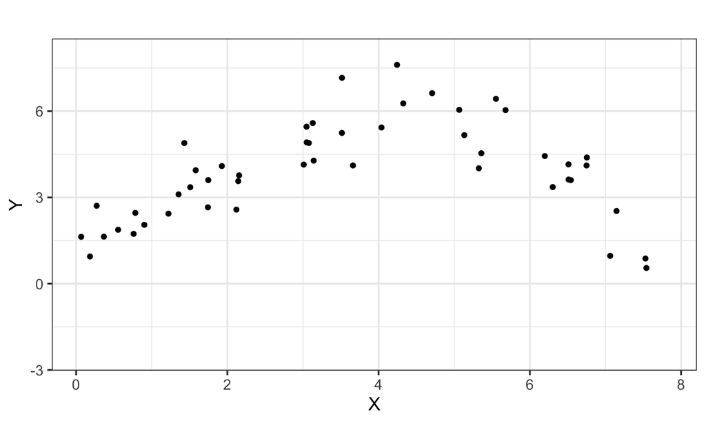

## How to assess model accuracy?

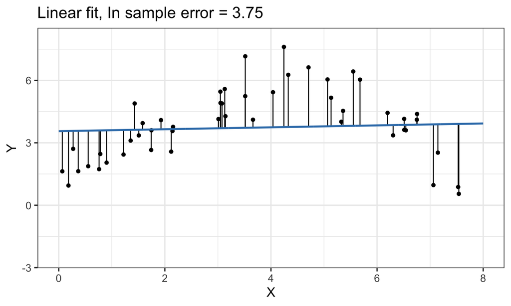

\[Y = \beta_0 + \beta_1 x\]

## How to assess model accuracy?

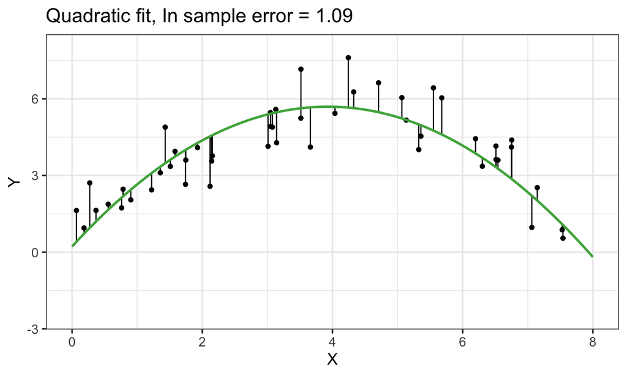

\[Y = \beta_0 + \beta_1 x + \beta_2 x^2\]

## How to assess model accuracy?

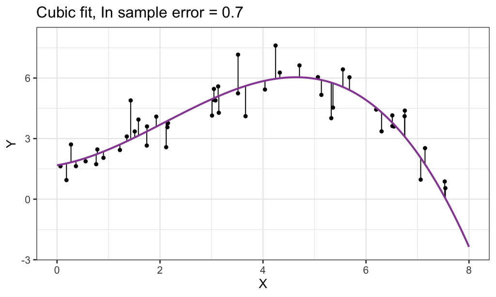

\[Y = \beta_0 + \beta_1 x + \beta_2 x^2 + \beta_3 x^3\]

## How to assess model accuracy?

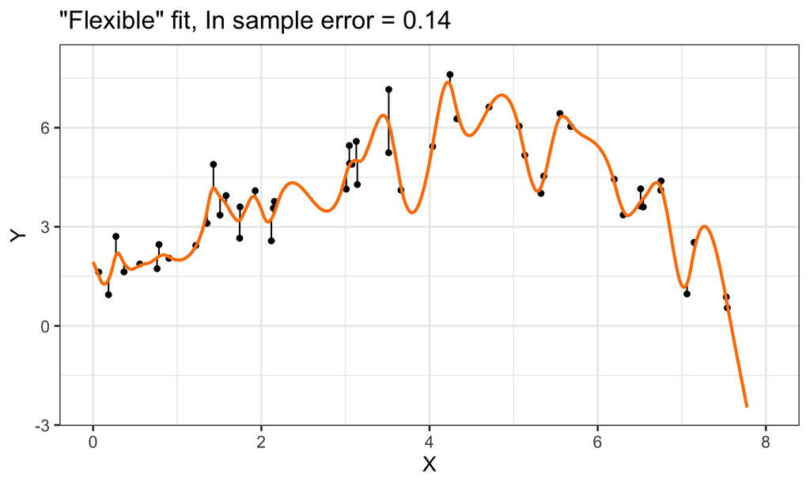

\[Y = ???\]

## How to assess model accuracy?

- As we have seen in the examples above, there are lots of options in estimating \(f(X)\)
- Some methods are very flexible some are not. Why would we ever choose a less flexible model?
  1. Simple, more restrictive methods are usually easier to **interpret**
  2. More importantly, it is often the case that simpler models are more **accurate** in making future predictions

Not too simple, but not too complex!

## How to assess model accuracy?

Suppose we fit a model \(\hat{f}(x)\) to some training data \(\text{Tr} = \{x_i, y_i\}_{i=1}^{n}\), and we wish to see how well it performs.

We could compute the average squared prediction error over Tr, i.e. \[\text{MSE}_{Tr} = \frac{1}{n} \sum_{i \in Tr} \left\{y_i - \hat{f}(x_i) \right\}^2\]

This is usually biased toward more complex models.

Instead we should, if possible, compute it using “fresh” test data \(\text{Te} = \{x_i^\star, y_i^\star\}_{i = 1}^{m}\), i.e. \[\text{MSE}_{Te} = \frac{1}{m} \sum_{i \in Te} \left\{y_i^\star - \hat{f}(x_i^\star) \right\}^2\]

## How to assess model accuracy?

### What if I was hiding some test data?

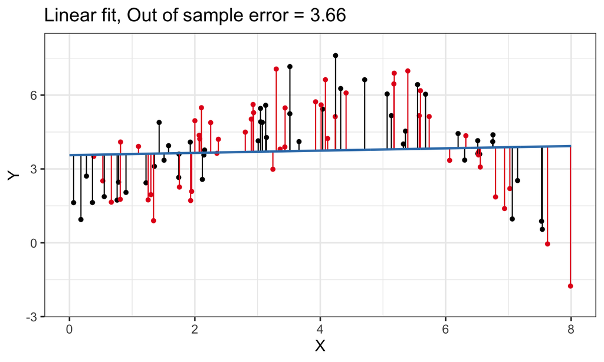

## How to assess model accuracy?

### What if I was hiding some test data?

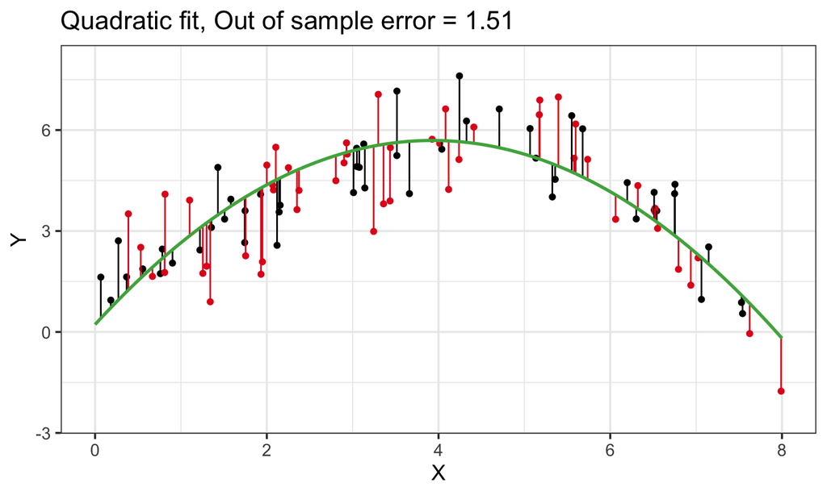

## How to assess model accuracy?

### What if I was hiding some test data?

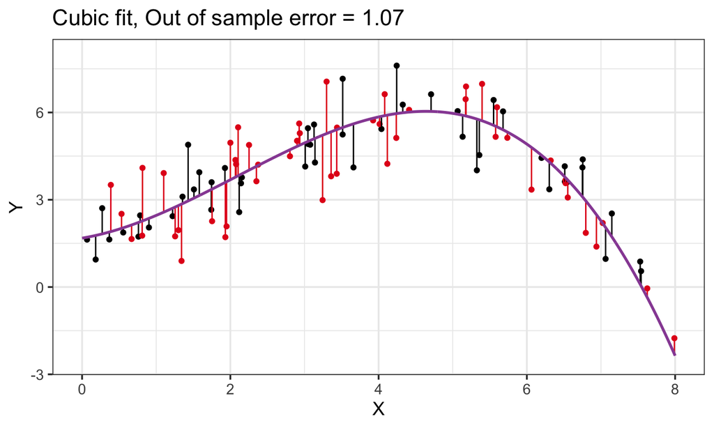

## How to assess model accuracy?

### What if I was hiding some test data?

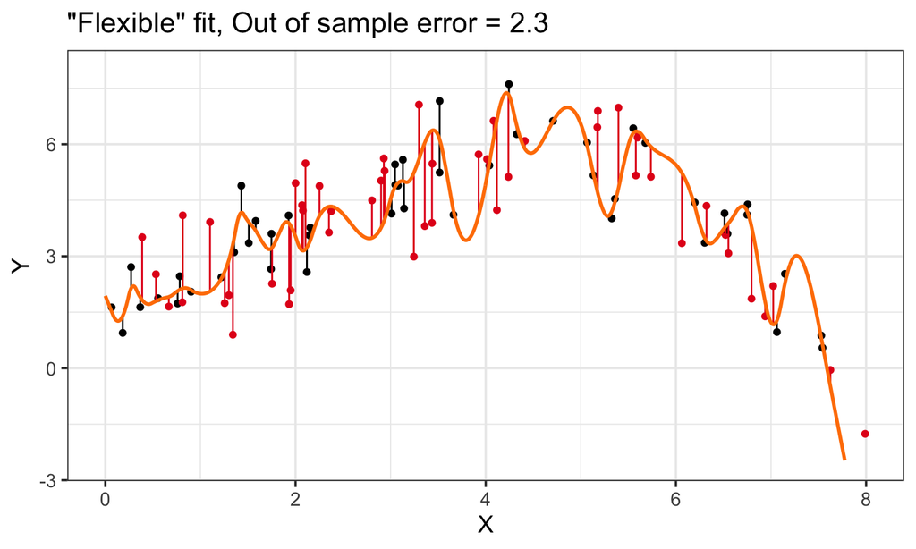

## General pattern

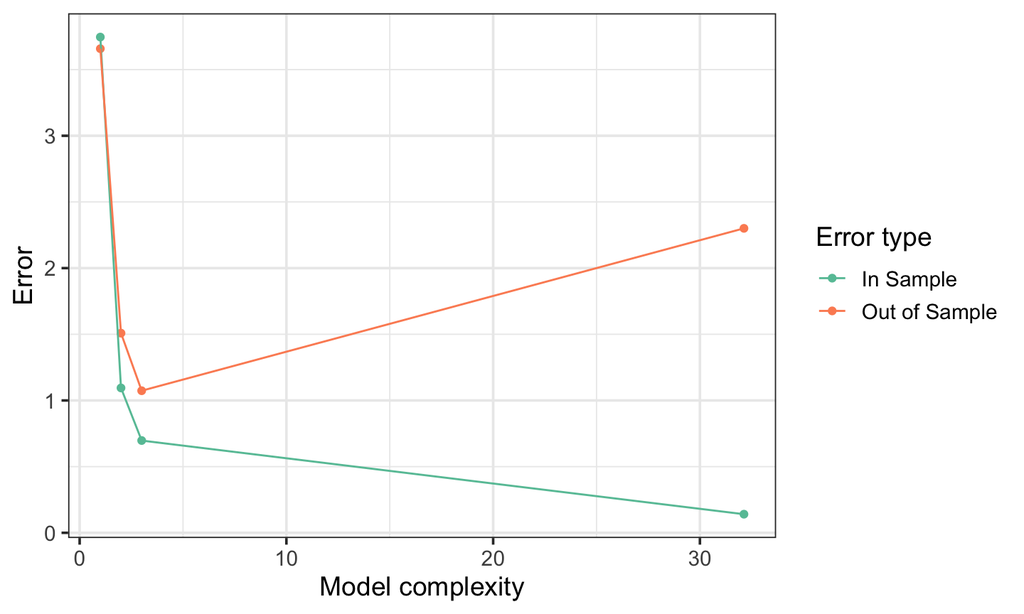

## The bias-variance tradeoff

**Bias**: how does the model perform, i.e. what is the distance between the predicted value and the true value.

**Variance**: how “sensitive” are the predicted values when new data is obtained.

[figure not shown]

More to come in this course!

## The bias-variance tradeoff

- Why under-fitting is bad?
- Why over-fitting is bad?
- How do we know when the fit is just right?

Typically as the flexibility (complexity) of \(f(x)\) increases, its variance increases, and its bias decreases.

In order to control this behaviour, a **penalty** for models that are too complex should be used.

How to quantify the degree of this penalty? Based on average **test error**, not on training error.

## The bias-variance tradeoff

- Suppose we have fit a model \(\hat{f}(x)\) to some training data Tr, and let \((x_0,y_0)\) be a test observation drawn from the population. If the true model is \(Y = f(X) + \varepsilon\) (with \(f(x) = \mathbb{E}[Y \mid X = x]\)), then \[\mathbb{E}[y_0 - \hat{f}(x_0)]^2 = \text{Var}(\hat{f}(x_0)) + [\text{Bias}(\hat{f}(x_0))]^2 + \text{Var}(\varepsilon)\]
- The expectation averages over the variability of \(y_0\) as well as the variability in Tr. Note that \(\text{Bias}(\hat{f}(x_0)) = \mathbb{E} [\hat{f}(x_0)] - f(x_0)\).
- Typically as the flexibility of \(\hat{f}\) increases, its variance increases, and its bias decreases. So choosing the flexibility based on average test error amounts to a bias-variance trade-off.

## The flexibilty-interpretability tradeoff

There is a natural tradeoff between:

- Inference: understanding the way that Y is affected as X changes: “Which media contribute to sales?”; “Which media generate the biggest boost in sales?”
- Prediction: predict the value of \(Y\) for new possible values of \(X\)

## The flexibilty-interpretability tradeoff

[figure not shown]

## Classification example

## The setting

Here the response variable \(Y\) is qualitative, e.g. e-mail is one of \(\mathcal{C} = \{\text{spam}, \text{not spam}\}\), digit class is one of \(\mathcal{C} = \{0, 1, \dots, 9\}\).

Our goals are to:

- Build a classifier \(C(X)\) that assigns a class label from \(\mathcal{C}\) to a future unlabeled observation \(X\)
- Assess the uncertainty in each classification
- Understand the roles of the different predictors among \(X = (X_1, X_2, \dots, X_p)\)

## A first simple algorithm

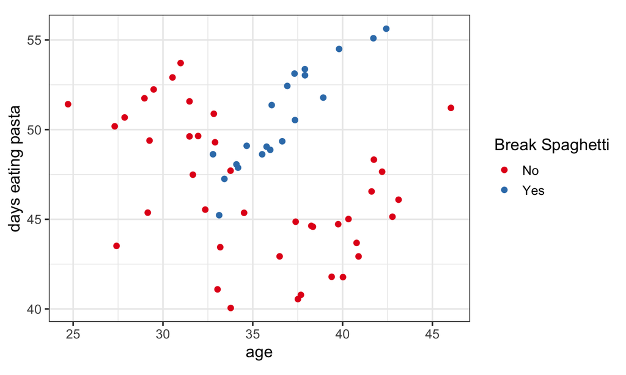

## A first simple algorithm

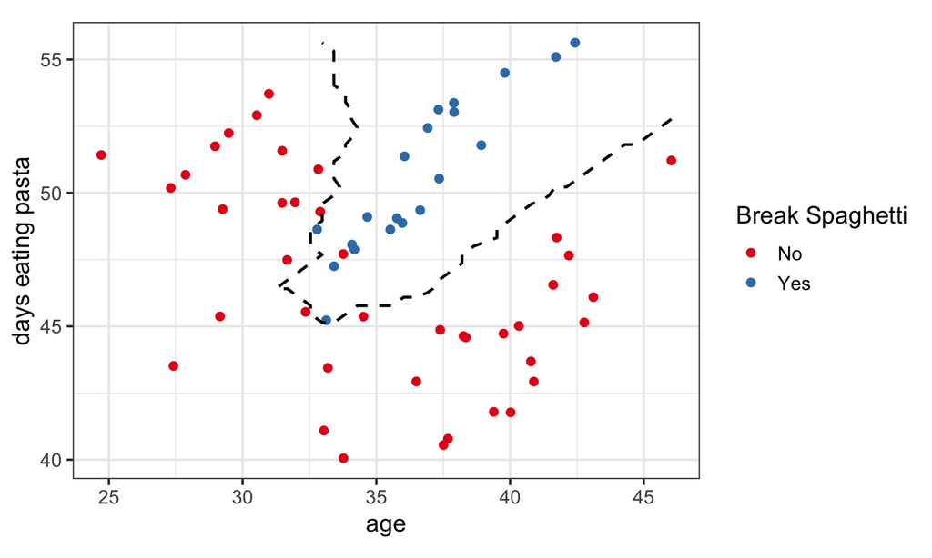

## Recap

## k-NN for regression

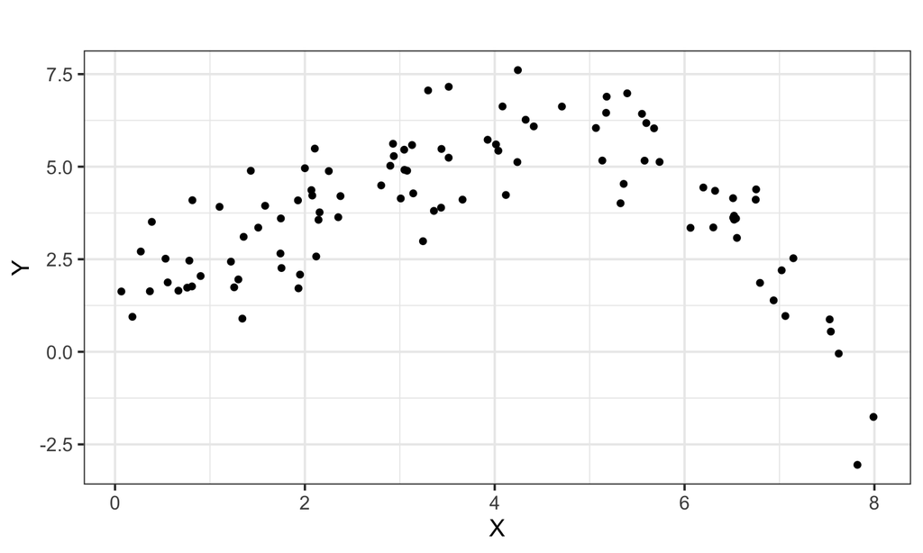

## k-NN for regression

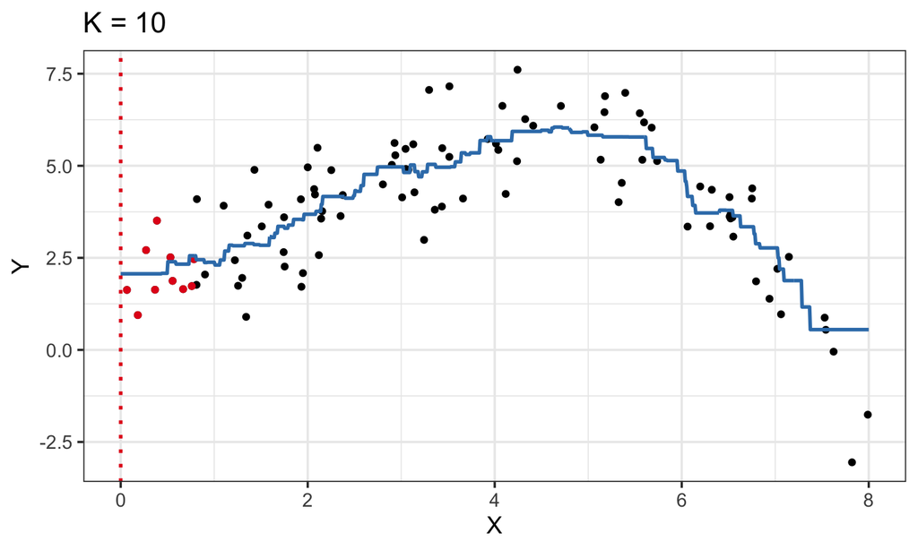

## k-NN for regression

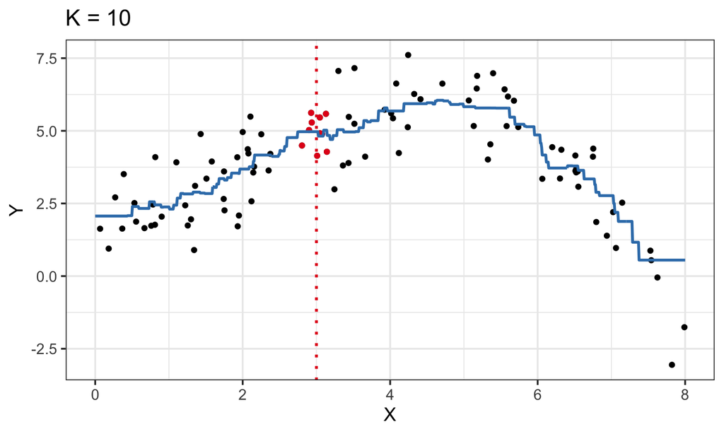

## k-NN for regression

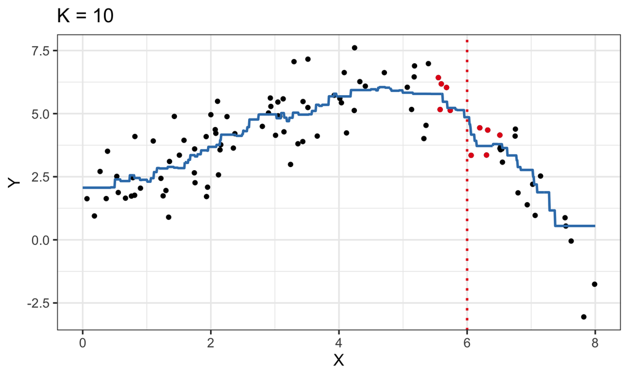

## k-NN for regression

### Let’s change \(k\)

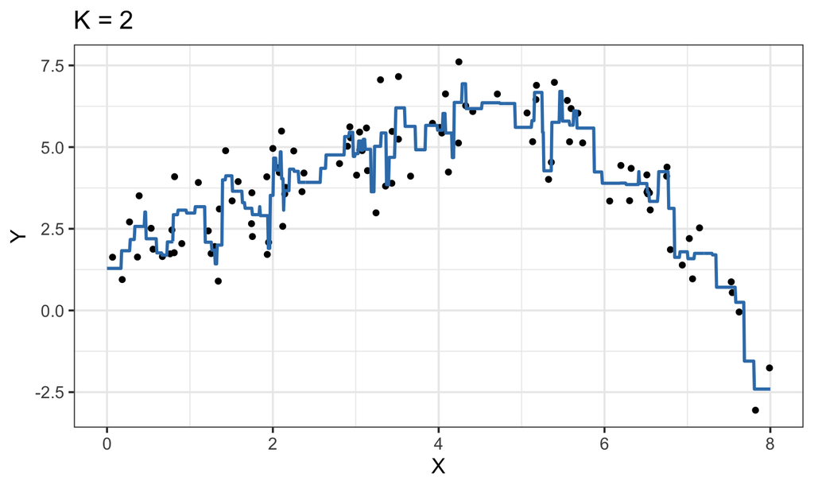

## k-NN for regression

### Let’s change \(k\)

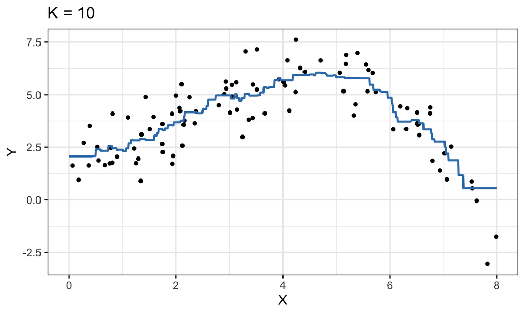

## k-NN for regression

### Let’s change \(k\)

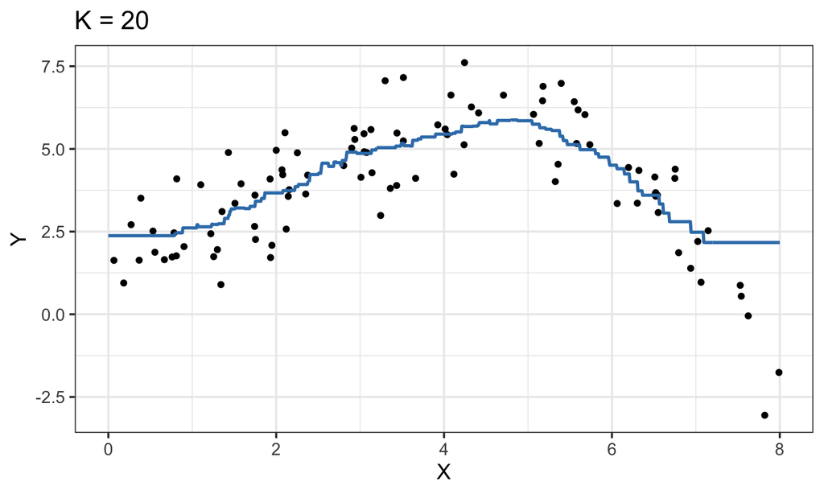

## k-NN for regression

### Let’s change \(k\)

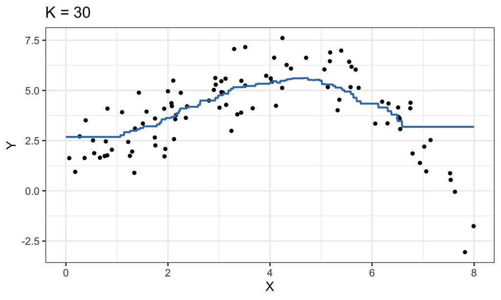

## k-NN for regression

### Let’s change \(k\)

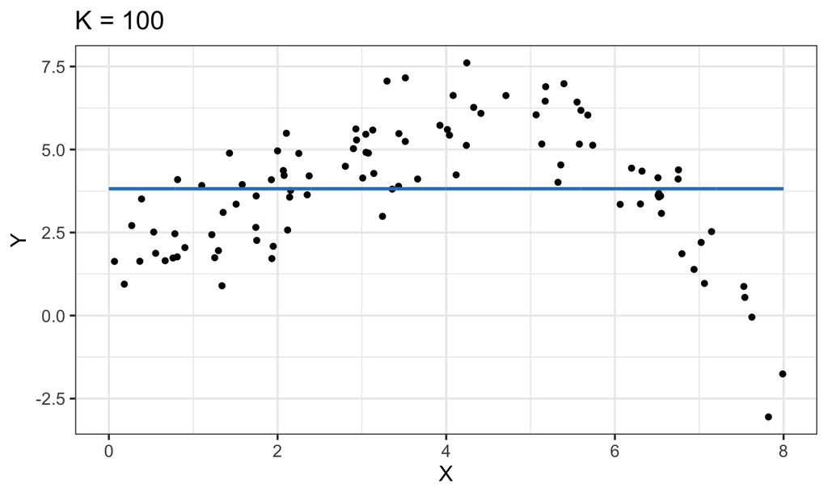